# Recommender System EDA practical Assignment:

## Task To do

**Perform an Exploratory Data Analyst using the datasets in order to have a better understanding on the different dataset**:

We are in this project performing an EDA on movies dataset focus on **user ratings** , **movie ids** and **movie titles** because they could be use for the creation of the recommender system.

**So as orientation goal we will try to make :**

- Analysis by user ratings, movie ids and movie titles:
  - What is the distribution of ratings, movie ids and titles
  - What item has relationship with high user ratings : userId? movie Id? movie titles? popularity? budget? etc.
    - What are the top movies sorted on the basis of user ratings on a particular movie ?
    - Which item explained the previous question: budget? popularity? movie titles? etc.
    - How likely the user rating will be for a movie ?
- and more if needed.

**That is why we need distribution of rating, movieId and movie titles and more**

The movies dataset -> https://www.kaggle.com/rounakbanik/the-movies-dataset

# 1. Loading the required datasets

## First we import all the useful libraries

- Path for filepath managing
- pandas and numpy for dataframe manip
- and for dataviz seaborn and matplotlib

```python
from pathlib import Path

import numpy as np
import pandas as pd
# To be able to see all columns
pd.options.display.max_columns = 25
```

```python
# Sometimes i don't want to see warnings
import warnings
warnings.filterwarnings("ignore")
```

## We organise our different files directories

```python
DATA_DIR = Path('../data')
RAW_DIR = DATA_DIR / 'raw'
PROCESSED_DIR = DATA_DIR / 'processed'
```

## We load the different PROCESSED datasets into dataframes using Pandas

- user rating is on ratings_small dataset
- movies titles is on movies_metadata dataset
- movies id are on every dataset BUT we are focus on user rating and movies titles for the moment so we will only upload ratings_small and movies_metadata

```python
ratings_df = pd.read_csv(PROCESSED_DIR / 'ratings_small.csv')
movies_meta_df = pd.read_csv(PROCESSED_DIR / 'movies_meta.csv')
display(ratings_df.sample(5))
display(movies_meta_df.sample(3))
```

|  | userId | movieId | rating | date | rating_year |
| --- | --- | --- | --- | --- | --- |
| 7339 | 47 | 10 | 4.0 | 1996-05-16 08:42:11 | 1996 |
| 29610 | 213 | 4121 | 2.5 | 2016-05-07 20:01:25 | 2016 |
| 50660 | 373 | 1913 | 4.0 | 1999-10-06 20:35:48 | 1999 |
| 20639 | 139 | 2918 | 3.0 | 2003-10-23 00:16:19 | 2003 |
| 78168 | 544 | 34542 | 5.0 | 2015-07-02 00:02:55 | 2015 |

|  | adult | budget | genres | movieId | imdb_id | original_language | original_title | overview | popularity | poster_path | production_companies | production_countries | release_date | revenue | runtime | spoken_languages | status | title | video | vote_average | vote_count | release_year |
| --- | --- | --- | --- | --- | --- | --- | --- | --- | --- | --- | --- | --- | --- | --- | --- | --- | --- | --- | --- | --- | --- | --- |
| 25299 | False | 0.0 | Crime\|Action | 67467 | tt0078655 | ru | Mesto Vstrechi Izmenit Nelzya | After WWII is over, a young officer Volodya Sh... | 0.994758 | /iVzabDu031Io6xbdg2yNDgpmAzr.jpg | Odessa Film Studios\|Gosteleradio | Russia | 1979-11-11 | 0.0 | 359.0 | Pусский | Released | Can't Change the Meeting Place | False | 7.5 | 10.0 | 1979 |
| 26152 | False | 0.0 | Horror | 173080 | tt0093115 | en | Graveyard Shift | Night brings out the hunger in people, especia... | 0.004351 | /7EaX1xIZjwvLBMz35BJaRdpvxgC.jpg | Lightshow Communications\|Cinema Ventures | Canada | 1987-06-12 | 0.0 | 89.0 | English | Released | Graveyard Shift | False | 7.0 | 1.0 | 1987 |
| 4631 | False | 0.0 | Drama\|History\|Thriller | 2721 | tt0065234 | fr | Z | Repression is the rule of the day in this film... | 11.943621 | /AshFxEhbFe9Mi3YjAv5btbxgX9s.jpg | Valoria Films | Algeria\|France | 1969-02-26 | 83305.0 | 127.0 | English\|Français\|Pусский | Released | Z | False | 8.0 | 87.0 | 1969 |

# 2. Data Exploration :

We are going to perform any additional steps (merging multiple dataset, selecting columns, creating additional columns, etc.)

## 2.1. Joining using "movieId"

We will merge the metadata with the rating dataset

```python
movies_df = movies_meta_df.join(ratings_df.set_index('movieId'), on ='movieId', how='inner')
movies_df.sample(2)
```

|  | adult | budget | genres | movieId | imdb_id | original_language | original_title | overview | popularity | poster_path | production_companies | production_countries | ... | runtime | spoken_languages | status | title | video | vote_average | vote_count | release_year | userId | rating | date | rating_year |
| --- | --- | --- | --- | --- | --- | --- | --- | --- | --- | --- | --- | --- | --- | --- | --- | --- | --- | --- | --- | --- | --- | --- | --- | --- | --- |
| 3493 | False | 8000000.0 | Drama\|Thriller | 318 | tt0120753 | en | The Million Dollar Hotel | The Million Dollar Hotel starts with a jump fr... | 4.938231 | /4wxOzpCjXY2RQgS3YoHuvKdItTF.jpg | Kintop Pictures | United States of America\|Germany | ... | 122.0 | English | Released | The Million Dollar Hotel | False | 5.9 | 76.0 | 2000 | 440 | 5.0 | 1996-06-21 08:03:16 | 1996 |
| 560 | False | 0.0 | Comedy\|Drama\|Romance | 2021 | tt0113448 | en | Jack & Sarah | Jack always lands on his feet. He lands on his... | 1.523446 | /vK6fm3T3FZxzYT4jDirKBp0SCSL.jpg | Granada Film Productions\|Mainstream S.A.\|Canal... | France\|United Kingdom | ... | 110.0 | English | Released | Jack & Sarah | False | 5.1 | 10.0 | 1995 | 77 | 3.5 | 2006-11-08 17:49:04 | 2006 |

2 rows × 26 columns

#### Quit check of preprocessing

```python
# The shape
print('shape: ',movies_df.shape)
# missing values
display(movies_df.isnull().sum())
# duplicated
print('Number of item duplicated or not \n:',movies_df.duplicated().value_counts())
```

```
shape:  (42249, 26)
```

```
adult                   0
budget                  0
genres                  0
movieId                 0
imdb_id                 0
original_language       0
original_title          0
overview                0
popularity              0
poster_path             0
production_companies    0
production_countries    0
release_date            0
revenue                 0
runtime                 0
spoken_languages        0
status                  0
title                   0
video                   0
vote_average            0
vote_count              0
release_year            0
userId                  0
rating                  0
date                    0
rating_year             0
dtype: int64
```

```
Number of item duplicated or not
: False    42249
dtype: int64
```

> Everything seems to be good ( No duplicated, No null values )

```python
# renaming date to rating_date for convenience
movies_df = movies_df.rename(columns = {'date':'rating_date'})
```

## 2.2. Categorical, Numerical, Text and Timestamp

```python
# Let us create list of correspondant columns :
categorical_columns = ['adult', 'movieId', 'imdb_id','original_language', 'status', 'video', 'userId', 'rating', 'original_title', 'title']
numerical_columns = ['budget','popularity', 'revenue', 'runtime', 'vote_average', 'vote_count']
text_or_mutilple_cat_columns = ['genres', 'overview','poster_path', 'production_companies', 'production_countries', 'spoken_languages']
timestamp_columns = ['release_date', 'rating_date', 'release_year', 'rating_year']
```

> - In our exploratory we will use categorical_columns, numerical_columns and timestamp_columns

## 2.3. Ratings, movies Id, movies Titles

So we decided to make :

- Analysis by user ratings, movie ids and movie titles:
  - What is the distribution of ratings, movie ids and titles
  - What item has relationship with high user ratings : userId? movie Id? movie titles? popularity? budget? etc.:
    - What are the top movies sorted on the basis of user ratings on a particular movie ?
    - Which item explained the previous question: budget? popularity? movie titles? etc.
    - How likely the user rating will be for a movie ?
- and more if needed.

**That is why we need distribution of rating, movieId and movie titles and more**

```python
# importing the function for dataviz
import sys
sys.path.append('../package_folder')

from dataviz import show_pie_box_kde, show_box_kde, show_sparsity, show_top20_vs_target
```

### 2.3.1. Distributions

# Ratings

```python
movies_df.rating.describe()
```

```
count    42249.000000
mean         3.561138
std          1.053389
min          0.500000
25%          3.000000
50%          4.000000
75%          4.000000
max          5.000000
Name: rating, dtype: float64
```

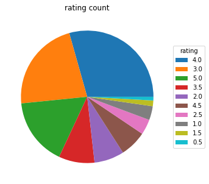

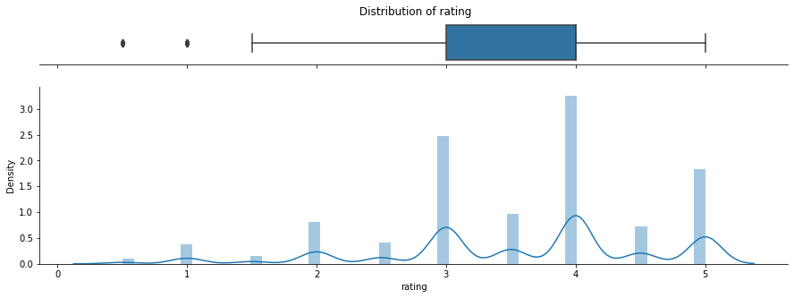

```python
show_pie_box_kde(movies_df, 'rating')
```

> We can observe the following pattern:
> - the most user rating is 4
> - 50% (half) of the user rating is between 3 and 4
> - 25% of user rating are less than 3 and 25% of user ratings are more than 4
> - The minimum excluding outlier is 1.5 and the maximum is 5
> - There are small outlier in user ratings